# Tentatively ID RC3 CY23 sites

PR

2023-04-26

### Overview

The general goal here is to identify ~20 sites across YRB that will (hopefully) capture differences in ecosystem respiration driven by the Schneider Springs fire. The data used aren’t synced with Github because shapefiles are too big…

### First, bring in and visualize sites by burn type

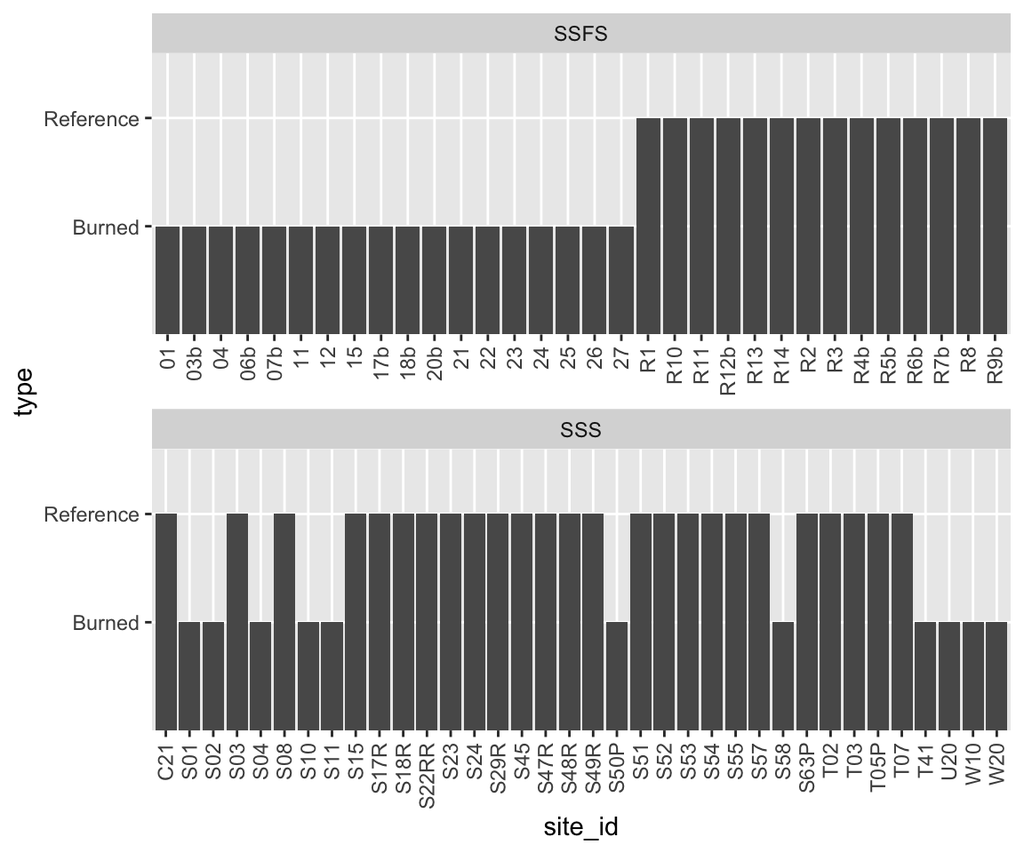

We’ll focus first on SSS sites since we have historic data for them. In particular, we should focus on sites that have **pre-fire (SS21)** data. So. Sites ID’ed as burned are:

```
##  [1] "S01"  "S02"  "S04"  "S10"  "S11"  "S50P" "S58"  "T41"  "U20"  "W10"
## [11] "W20"
```

Of these 11 sites, only 3 were in the SS21 campaign:

```
## [1] "W20" "W10" "U20"
```

Now, let’s see which unburned sites were sampled in SS21:

```
##  [1] "S17R" "S15"  "S23"  "S18R" "S51"  "S49R" "S55"  "S29R" "T07"  "T02"
## [11] "T03"
```

So this is interesting! If we included the 11 reference sites that have data for SS21 and SS22, and the 11 burned SSS site (of which 3 were included in both SS21 and SS22), we’d have 22 sites. It’s not ideal that we don’t have pre-fire data for most of the impacted sites, but this looks like a nice potential group. Let’s use histograms to see if distributions of potential drivers of respiration differ between burned and unburned (reference) groups.

```
##  [1] "S01"  "S02"  "S04"  "S10"  "S11"  "S50P" "S58"  "T41"  "U20"  "W10"
## [11] "W20"  "S17R" "S15"  "S23"  "S18R" "S51"  "S49R" "S55"  "S29R" "T07"
## [21] "T02"  "T03"
```

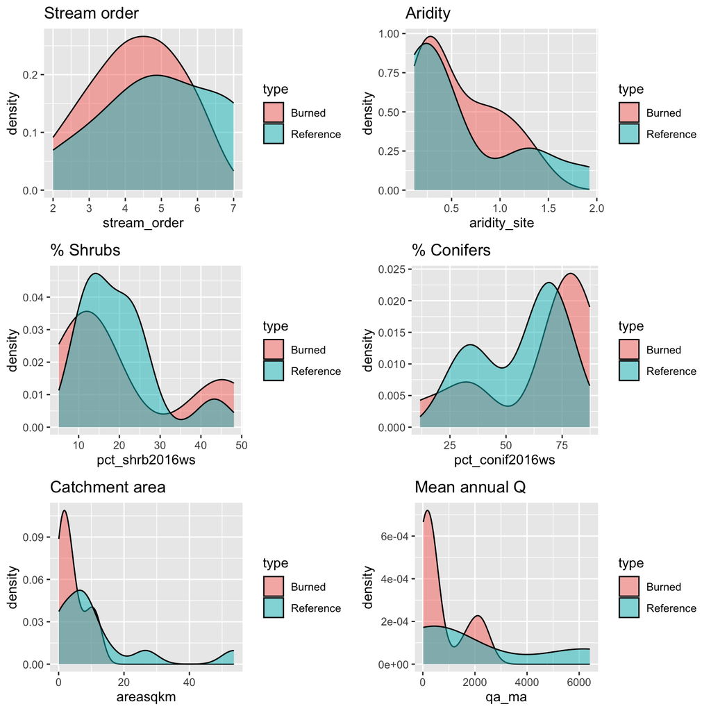

*I have not looked at SSFS sites*. My priority here is more data for sites we use, since we’ve got spatial in spades, but temporal is limiting and is an important consideration. Also interpreting a single point in time for some sites and not others feels hard to defend to me.

Adding a quick map to visualize the spatial distributions of sites

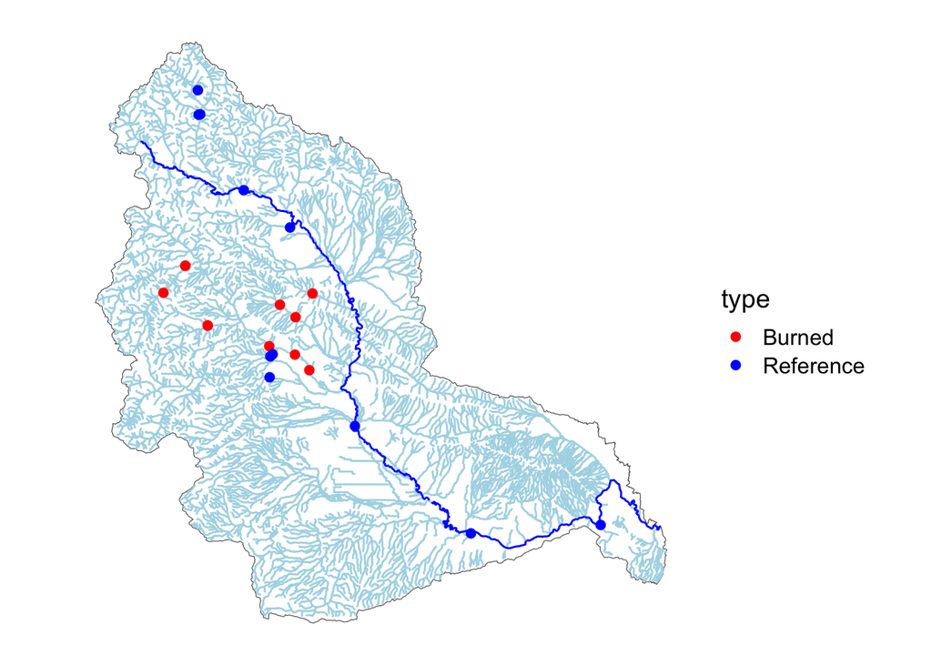